# IODS course project

Neli Noykova

# Introduction to Open Data Science

This course is a brief introduction to data science - what to do with the big amount of data, how to model them and extract important information, which could be used later on for analyses and predictions. The course will teach us how to use GitHUb (system for version control) to share results. The modeling of data will be performed using R.

## 1. Tools and methods for open and reproducible research

First step is to learn basic GitHub commands as fork, copy, commit. We have to make our first steps in R as well. The goal of creating this document is to learn how to create markdown documents and share them on the net using GitHub.

Here is a link to to the GitHub page, related to my work on this course:

https://github.com/noykova/IODS-project

# 2.Regression and model validation

## 2.1. Reading the data

Here we use part of the sociological data described [here](http://www.helsinki.fi/~kvehkala/JYTmooc/JYTOPKYS3-meta.txt). The data concern learning process of students. The full data consists of 183 observations of 60 variables. After wrangling the data into a format that is easy to analyze we have obtained 166 observations of 7 variables.

Thus the data set, used in this analysis, includes 166 observations of the following variables: gender,age, attitude, deep, stra, surf and points, where gender and age are the gender (F/M) and age of the students, and collected points>0.

The R code about wrangling described above is given [here](https://github.com/noykova/IODS-project/blob/master/Data/create_learning2014.R)

The data are read using the following command:

```r
lrn14 <- read.table("learning2014.txt", header=TRUE)
dim(lrn14)
```

```
## [1] 166   7
```

```r
str(lrn14)
```

```
## 'data.frame':    166 obs. of  7 variables:
##  $ gender  : Factor w/ 2 levels "F","M": 1 2 1 2 2 1 2 1 2 1 ...
##  $ age     : int  53 55 49 53 49 38 50 37 37 42 ...
##  $ attitude: int  37 31 25 35 37 38 35 29 38 21 ...
##  $ deep    : num  3.58 2.92 3.5 3.5 3.67 ...
##  $ stra    : num  3.38 2.75 3.62 3.12 3.62 ...
##  $ surf    : num  2.58 3.17 2.25 2.25 2.83 ...
##  $ points  : int  25 12 24 10 22 21 21 31 24 26 ...
```

## 2.2 Graphical overview of the data and summaries of the variables

Access the GGally and ggplot2 libraries

```r
library(GGally)
library(ggplot2)
```

Next we create a more advanced plot matrix with ggpairs() The purpose of this function is to display two grouped data in a plot matrix. Analysis of this plot is used for roughly determining if we have a linear correlation between data.

```r
p <- ggpairs(lrn14, mapping = aes(col=gender, alpha=0.3), lower = list(combo = wrap("facethist", bins = 20)))
```

In this function the elements are:

**mapping** is an aestetic mapping between variables **aes** - defines how the variables in the data are mapped via parameters in geom_bar

**col** should be a categorical variable, for which different colors are used.

**alpha** - for large datasets with overlapping the alpha aestetic will make the points more transparent.

**lower (or upper)** are lists that may contain the variables continuous, combo, discete or na. Each element may be a function or a string.

**combo** - this option is used either continuous X and categorical Y or categorical X and continuous Y. It could take values box, box-no-facet, dot, dot-no-facet, facetist, facet density, blank.

If **lower (or upper or diagonal)** lists are supplied, the **combo** option should be presented using a **function(data, mapping)**. If a specific function **fn** needs its parameter set, then the function with its parameters should be of the form **wrap(fn, param1 = val1, param2 = val2)**

**facets** - create a subplot of each group and draw the subplots side by side.

**facets_wrap** - subplots are paid out horizontally and wrap around.

**stat_bin** - bins (binwidth) are bars used for representation of categorical data. By default **bins** are 1/30 of the range of data.

This code produce the following plot:

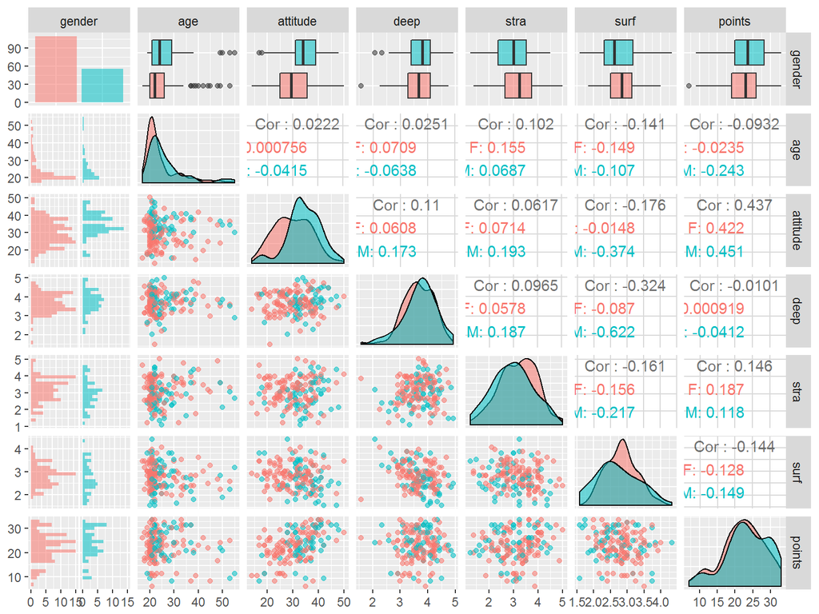

```r
p
```

The graphs on the diagonal reflect the marginal distributions of the variables.

On the first top row the boxplot of the categorical variable gender depending on each of the other corresponding variables is shown. The marginal distribution of gender shows that the observed female students group is bigger, while male students tend to be a little older, have higher attitude and get a little bit better points.

The histograms in first column represent dependence of points, surf, stra, deep, attitude and age on categorical variable gender for its two values (M/F) separately.

The scatter plots under the diagonal represent the dependence of each pair of corresponding variables. As the matrix is symmetric, on the upper part of it the correlation coefficients for every pair and also separated by gender M/F are calculated and shown.

From the graphics of diaconal elements we see that the marginal distribution of variables stra and deep are very near to normal.

Thus we can make a hypothesis that the variable points depends on attitude (Cor = 0.437), stra (Cor = 0.146), and surf(Cor = -0.144) because the absolute value of the correlation coefficient is higher for these variables.

In order to exclude the effect of multicollinearity during next step of multiple regression we check the correlations among the pairs variables, which are candidates for dependen variables. If variables are correlatd, it becomes very difficult for the model to determine the true effect of independent variables on dependent variable.

From the matrix plot above we observe that Cor(stra, attitude) = 0.0617, Cor(surf,attitude) = -0.176 (quite significant), and Cor(stra,surf) = -0.161 (quite significant). Usually, correlation above 80% (subjective assumption) is considered higher. Therefore at thi stage we do not consider for removing any variable.

## 2.3 Multiple regression: summary of results, analyses, conclusions.

The function lm in R is used for linear reglession. We create a regression model with multiple explanatory variables attitude, stra, surf. The choice of independent variables is based on the analysis in 2. Points is chosen as dependent variable.

```r
my_model <- lm(points ~ attitude + stra + surf, data = lrn14)
```

Print the summary of the model:

```r
summary(my_model)
```

```
##
## Call:
## lm(formula = points ~ attitude + stra + surf, data = lrn14)
##
## Residuals:
##      Min       1Q   Median       3Q      Max
## -17.1550  -3.4346   0.5156   3.6401  10.8952
##
## Coefficients:
##             Estimate Std. Error t value Pr(>|t|)
## (Intercept) 11.01711    3.68375   2.991  0.00322 **
## attitude     0.33952    0.05741   5.913 1.93e-08 ***
## stra         0.85313    0.54159   1.575  0.11716
## surf        -0.58607    0.80138  -0.731  0.46563
## ---
## Signif. codes:  0 '***' 0.001 '**' 0.01 '*' 0.05 '.' 0.1 ' ' 1
##
## Residual standard error: 5.296 on 162 degrees of freedom
## Multiple R-squared:  0.2074, Adjusted R-squared:  0.1927
## F-statistic: 14.13 on 3 and 162 DF,  p-value: 3.156e-08
```

From this statistic we observe that the residuals median is quite high(0.51). If the residuals are normally distributed, this indicates that the mean of the difference between the predictions and actual values is close to 0.

Next we analyse the parameter estimates and their standard errors. The intersect is beta0 value. It’s prediction is made by model when all independent variables are set to 0. We observe that the standard error of regression coefficient for surf is bigger than the parameter estimate itself. Also the standard error of regression coefficient for stra is relatively high.

The last column pf coefficients statistics show the p-value for the corresponding regression coefficient. When p values < 0.05 it is assumed that the corresponding coefficient is significant. We observe p>0.05 for regression coefficients for stra and surf.

From the analysis of the statistics we observe that variables surf and stra could be excluded from the model.

Next perform multiple regression for two variables. First include (attitude, stra), and next - (attitude,surf)

Finally we provide simple regression excluding both stra and surf variables.

```r
my_model21 <- lm(points ~ attitude + stra, data = lrn14)

summary(my_model21)
```

```
##
## Call:
## lm(formula = points ~ attitude + stra, data = lrn14)
##
## Residuals:
##      Min       1Q   Median       3Q      Max
## -17.6436  -3.3113   0.5575   3.7928  10.9295
##
## Coefficients:
##             Estimate Std. Error t value Pr(>|t|)
## (Intercept)  8.97290    2.39591   3.745  0.00025 ***
## attitude     0.34658    0.05652   6.132 6.31e-09 ***
## stra         0.91365    0.53447   1.709  0.08927 .
## ---
## Signif. codes:  0 '***' 0.001 '**' 0.01 '*' 0.05 '.' 0.1 ' ' 1
##
## Residual standard error: 5.289 on 163 degrees of freedom
## Multiple R-squared:  0.2048, Adjusted R-squared:  0.1951
## F-statistic: 20.99 on 2 and 163 DF,  p-value: 7.734e-09
```

```r
my_model22 <- lm(points ~ attitude + surf, data = lrn14)

summary(my_model22)
```

```
##
## Call:
## lm(formula = points ~ attitude + surf, data = lrn14)
##
## Residuals:
##     Min      1Q  Median      3Q     Max
## -17.277  -3.236   0.386   3.977  10.642
##
## Coefficients:
##             Estimate Std. Error t value Pr(>|t|)
## (Intercept) 14.11957    3.12714   4.515 1.21e-05 ***
## attitude     0.34264    0.05764   5.944 1.63e-08 ***
## surf        -0.77895    0.79556  -0.979    0.329
## ---
## Signif. codes:  0 '***' 0.001 '**' 0.01 '*' 0.05 '.' 0.1 ' ' 1
##
## Residual standard error: 5.32 on 163 degrees of freedom
## Multiple R-squared:  0.1953, Adjusted R-squared:  0.1854
## F-statistic: 19.78 on 2 and 163 DF,  p-value: 2.041e-08
```

```r
my_model1 <- lm(points ~ attitude, data = lrn14)

summary(my_model1)
```

```
##
## Call:
## lm(formula = points ~ attitude, data = lrn14)
##
## Residuals:
##      Min       1Q   Median       3Q      Max
## -16.9763  -3.2119   0.4339   4.1534  10.6645
##
## Coefficients:
##             Estimate Std. Error t value Pr(>|t|)
## (Intercept) 11.63715    1.83035   6.358 1.95e-09 ***
## attitude     0.35255    0.05674   6.214 4.12e-09 ***
## ---
## Signif. codes:  0 '***' 0.001 '**' 0.01 '*' 0.05 '.' 0.1 ' ' 1
##
## Residual standard error: 5.32 on 164 degrees of freedom
## Multiple R-squared:  0.1906, Adjusted R-squared:  0.1856
## F-statistic: 38.61 on 1 and 164 DF,  p-value: 4.119e-09
```

Therefore we decide to continue with both simple (points ~ attitude) and multiple (points ~ attitude + stra) regression models.

## 2.4 Analyses and interpretation of the model parameters and the multiple R squared of the model.

Interpretation of model parameters was provided above, in section 3.

R Square (Coefficient of Determination) is a metric used to determine goodness of model fit. This metric explains the percentage of variance explained by covariates in the model. It ranges between 0 and 1. Usually, higher values are desirable but it depends on the data quality and domain. For example, if the data is noisy, we can accept a model at low R Square values.

R-Squared can be graphically illustrated via plots of observed responses Versus fitted responses.

For single regression this plot is:

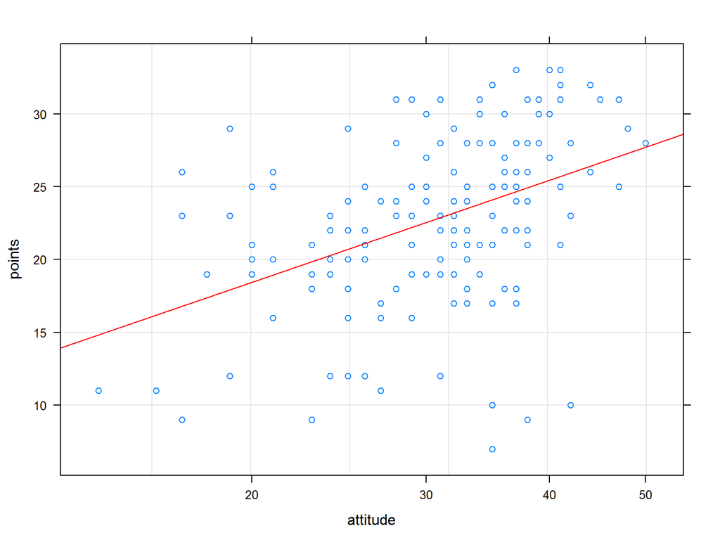

```r
library(lattice)
xyplot(points ~ attitude, lrn14, grid = TRUE,
       scales = list(x = list(log = 10, equispaced.log = FALSE)),
       type = c("p", "r"), col.line="red")
```